# Practical Machine Learning Course Project

Sofia Perez

11/4/2021

## Summary

Using devices such as Jawbone Up, Nike FuelBand, and Fitbit it is now possible to collect a large amount of data about personal activity relatively inexpensively. These type of devices are part of the quantified self movement – a group of enthusiasts who take measurements about themselves regularly to improve their health, to find patterns in their behavior, or because they are tech geeks. One thing that people regularly do is quantify how much of a particular activity they do, but they rarely quantify how well they do it.

In this project, we will use data from accelerometers on the belt, forearm, arm, and dumbell of 6 participants. They were asked to perform barbell lifts correctly and incorrectly in 5 different ways.

The goal of this project is to predict the manner in which they did the exercise. This is the “classe” variable in the training set.

## Getting and Cleaning Data

### Loading Data

```r
train_data <- read.csv("pml-training.csv")
valid_data  <- read.csv("pml-testing.csv")
```

### Cleaning Data

Removing NA values:

```r
training<- train_data[, colSums(is.na(train_data)) == 0]
validating <- valid_data[, colSums(is.na(valid_data)) == 0]
dim(training)
```

```
## [1] 19622    93
```

```r
dim(validating)
```

```
## [1] 20 60
```

Removing irrelevant data (first seven columns):

```r
training <- training[, -c(1:7)]
validating <- validating[, -c(1:7)]
dim(training)
```

```
## [1] 19622    86
```

```r
dim(validating)
```

```
## [1] 20 53
```

### Creating Partitions

```r
library(caret)
inTrain  <- createDataPartition(training$classe, p=0.7, list=FALSE)
training <- training[inTrain, ]
testing  <- training[-inTrain, ]
dim(training)
```

```
## [1] 13737    86
```

```r
dim(testing)
```

```
## [1] 4127   86
```

### Near zero variance

Removing near zero variance variables:

```r
nzv <- nearZeroVar(training)
training <- training[, -nzv]
testing  <- testing[, -nzv]
dim(training)
```

```
## [1] 13737    53
```

```r
dim(testing)
```

```
## [1] 4127   53
```

## Correlation Analysis

Correlation is analyzed in the graph below, dark colors represent high correlated variables.

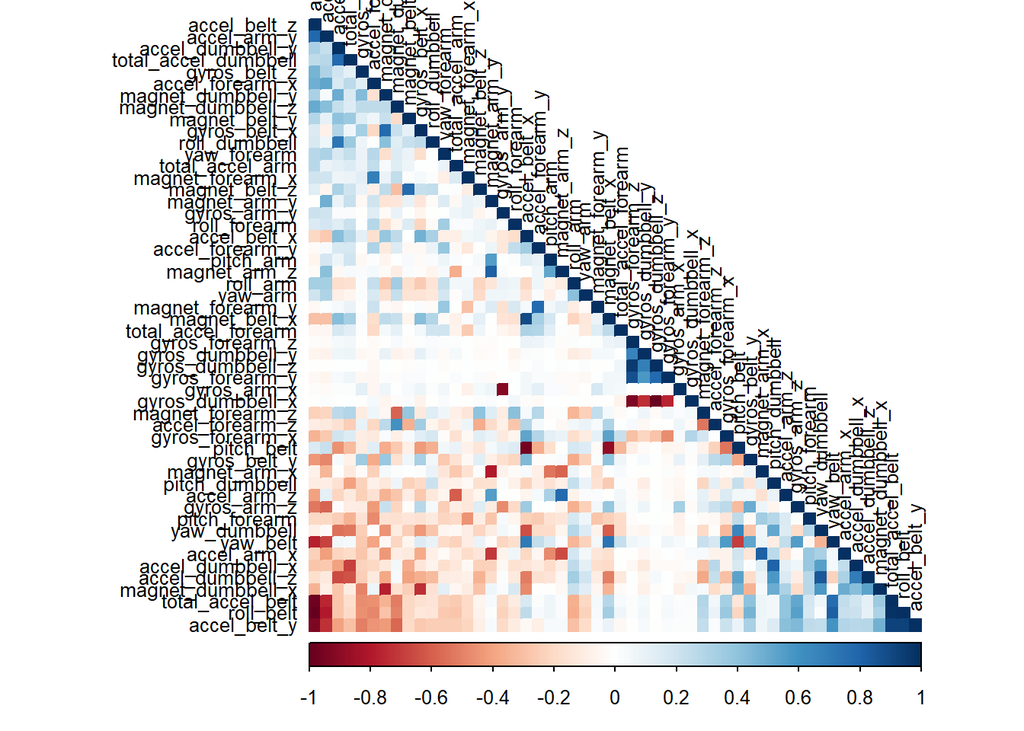

```r
library(corrplot)
cor_mx <- cor(training[, -53])
corrplot(cor_mx, order = "FPC", method = "color", type = "lower", tl.cex = 0.8, tl.col = rgb(0, 0, 0))
```

## Creating Model

For this project we will use different algorithms to predict the outcome and select the one with better accuracy:

1- Random Forest 2- Generalized Boosted Trees 2- Decision Tree 4- Support Vector Machine

```r
set.seed(12345)
control <- trainControl(method="cv", number=3, verboseIter=FALSE)
```

### Random Forest

```r
Mod_RF <- train(classe ~ ., data=training, method="rf", trControl=control)
Mod_RF$finalModel
```

```
##
## Call:
##  randomForest(x = x, y = y, mtry = param$mtry)
##                Type of random forest: classification
##                      Number of trees: 500
## No. of variables tried at each split: 2
##
##         OOB estimate of  error rate: 0.69%
## Confusion matrix:
##      A    B    C    D    E  class.error
## A 3904    1    0    0    1 0.0005120328
## B   14 2638    6    0    0 0.0075244545
## C    0   26 2368    2    0 0.0116861436
## D    0    0   39 2212    1 0.0177619893
## E    0    0    0    5 2520 0.0019801980
```

```r
Pred_RF <- predict(Mod_RF, testing)
confusionMatrix(Pred_RF, factor(testing$classe))
```

```
## Confusion Matrix and Statistics
##
##           Reference
## Prediction    A    B    C    D    E
##          A 1185    0    0    0    0
##          B    0  798    0    0    0
##          C    0    0  707    0    0
##          D    0    0    0  687    0
##          E    0    0    0    0  750
##
## Overall Statistics
##
##                Accuracy : 1
##                  95% CI : (0.9991, 1)
##     No Information Rate : 0.2871
##     P-Value [Acc > NIR] : < 2.2e-16
##
##                   Kappa : 1
##
##  Mcnemar's Test P-Value : NA
##
## Statistics by Class:
##
##                      Class: A Class: B Class: C Class: D Class: E
## Sensitivity            1.0000   1.0000   1.0000   1.0000   1.0000
## Specificity            1.0000   1.0000   1.0000   1.0000   1.0000
## Pos Pred Value         1.0000   1.0000   1.0000   1.0000   1.0000
## Neg Pred Value         1.0000   1.0000   1.0000   1.0000   1.0000
## Prevalence             0.2871   0.1934   0.1713   0.1665   0.1817
## Detection Rate         0.2871   0.1934   0.1713   0.1665   0.1817
## Detection Prevalence   0.2871   0.1934   0.1713   0.1665   0.1817
## Balanced Accuracy      1.0000   1.0000   1.0000   1.0000   1.0000
```

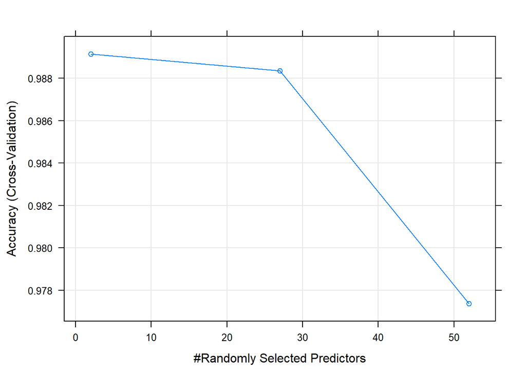

### Generalized Boosted Trees

```r
library(caret)
Mod_gbm <- train(classe ~ ., data=training, method="gbm", trControl = control, tuneLength = 5, verbose = FALSE)

Pred_gbm <- predict(Mod_gbm, testing)
confusionMatrix(Pred_gbm, factor(testing$classe))
```

```
## Confusion Matrix and Statistics
##
##           Reference
## Prediction    A    B    C    D    E
##          A 1185    0    0    0    0
##          B    0  798    0    0    0
##          C    0    0  707    0    0
##          D    0    0    0  686    0
##          E    0    0    0    1  750
##
## Overall Statistics
##
##                Accuracy : 0.9998
##                  95% CI : (0.9987, 1)
##     No Information Rate : 0.2871
##     P-Value [Acc > NIR] : < 2.2e-16
##
##                   Kappa : 0.9997
##
##  Mcnemar's Test P-Value : NA
##
## Statistics by Class:
##
##                      Class: A Class: B Class: C Class: D Class: E
## Sensitivity            1.0000   1.0000   1.0000   0.9985   1.0000
## Specificity            1.0000   1.0000   1.0000   1.0000   0.9997
## Pos Pred Value         1.0000   1.0000   1.0000   1.0000   0.9987
## Neg Pred Value         1.0000   1.0000   1.0000   0.9997   1.0000
## Prevalence             0.2871   0.1934   0.1713   0.1665   0.1817
## Detection Rate         0.2871   0.1934   0.1713   0.1662   0.1817
## Detection Prevalence   0.2871   0.1934   0.1713   0.1662   0.1820
## Balanced Accuracy      1.0000   1.0000   1.0000   0.9993   0.9999
```

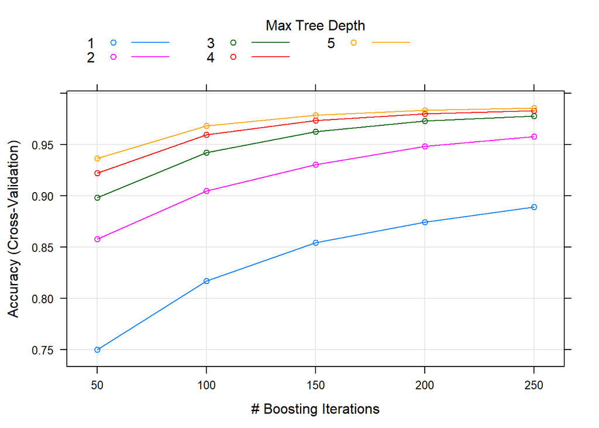

### Decision Trees

```r
library(rattle)
Mod_trees <- train(classe ~ ., data=training, method="rpart", trControl = control, tuneLength = 5)
Pred_trees <- predict(Mod_trees, testing)
confusionMatrix(Pred_trees, factor(testing$classe))
```

```
## Confusion Matrix and Statistics
##
##           Reference
## Prediction    A    B    C    D    E
##          A 1084  298  314  311  106
##          B   18  267   23    6   79
##          C   55   91  319   92   94
##          D   27  142   51  278  123
##          E    1    0    0    0  348
##
## Overall Statistics
##
##                Accuracy : 0.5563
##                  95% CI : (0.541, 0.5716)
##     No Information Rate : 0.2871
##     P-Value [Acc > NIR] : < 2.2e-16
##
##                   Kappa : 0.4217
##
##  Mcnemar's Test P-Value : < 2.2e-16
##
## Statistics by Class:
##
##                      Class: A Class: B Class: C Class: D Class: E
## Sensitivity            0.9148  0.33459   0.4512  0.40466  0.46400
## Specificity            0.6502  0.96215   0.9029  0.90029  0.99970
## Pos Pred Value         0.5130  0.67939   0.4900  0.44767  0.99713
## Neg Pred Value         0.9499  0.85779   0.8884  0.88334  0.89359
## Prevalence             0.2871  0.19336   0.1713  0.16646  0.18173
## Detection Rate         0.2627  0.06470   0.0773  0.06736  0.08432
## Detection Prevalence   0.5120  0.09523   0.1577  0.15047  0.08457
## Balanced Accuracy      0.7825  0.64837   0.6771  0.65247  0.73185
```

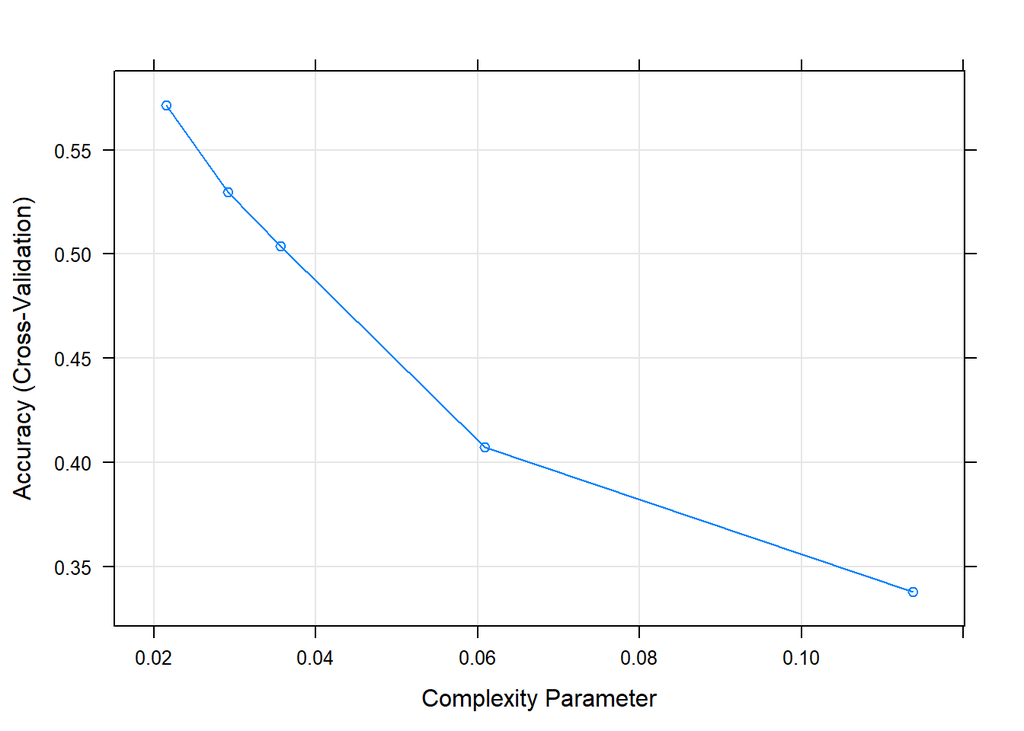

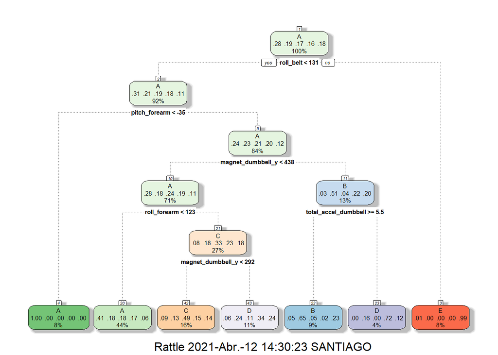

### Support Vector Machine

```r
Mod_svm <- train(classe ~ ., data=training, method="svmLinear", trControl = control, tuneLength = 5, verbose = FALSE)

Pred_svm <- predict(Mod_svm, testing)
confusionMatrix(Pred_svm, factor(testing$classe))
```

```
## Confusion Matrix and Statistics
##
##           Reference
## Prediction    A    B    C    D    E
##          A 1095   85   62   45   44
##          B   26  593   63   22   92
##          C   25   35  555   78   49
##          D   36   19   14  509   46
##          E    3   66   13   33  519
##
## Overall Statistics
##
##                Accuracy : 0.7926
##                  95% CI : (0.7799, 0.8049)
##     No Information Rate : 0.2871
##     P-Value [Acc > NIR] : < 2.2e-16
##
##                   Kappa : 0.7362
##
##  Mcnemar's Test P-Value : < 2.2e-16
##
## Statistics by Class:
##
##                      Class: A Class: B Class: C Class: D Class: E
## Sensitivity            0.9241   0.7431   0.7850   0.7409   0.6920
## Specificity            0.9198   0.9390   0.9453   0.9666   0.9659
## Pos Pred Value         0.8227   0.7450   0.7480   0.8157   0.8186
## Neg Pred Value         0.9678   0.9385   0.9551   0.9492   0.9339
## Prevalence             0.2871   0.1934   0.1713   0.1665   0.1817
## Detection Rate         0.2653   0.1437   0.1345   0.1233   0.1258
## Detection Prevalence   0.3225   0.1929   0.1798   0.1512   0.1536
## Balanced Accuracy      0.9219   0.8411   0.8652   0.8537   0.8290
```

## Selecting Model

The accuracy of the models above is:

|  | Accuracy |
| --- | --- |
| Random Forest | 1.0000000 |
| GBM | 0.9997577 |
| Decision Tree | 0.5563363 |
| SVM | 0.7925854 |

## Applying Model

After comparing the different models, we can conclude that Random Forest Model is more accurate and should be chosen.

### Applying Random Forest on Validation Data

```r
library(knitr)
Pred <- predict(Mod_RF, validating)
Results<-data.frame(cbind(valid_data[,1:2],Pred))
colnames(Results)<-c("id","user_name","Pred_classe")
kable(Results,align = "l",padding = 5, format='html')
```

| id | user_name | Pred_classe |
| --- | --- | --- |
| 1 | pedro | B |
| 2 | jeremy | A |
| 3 | jeremy | B |
| 4 | adelmo | A |
| 5 | eurico | A |
| 6 | jeremy | E |
| 7 | jeremy | D |
| 8 | jeremy | B |
| 9 | carlitos | A |
| 10 | charles | A |
| 11 | carlitos | B |
| 12 | jeremy | C |
| 13 | eurico | B |
| 14 | jeremy | A |
| 15 | jeremy | E |
| 16 | eurico | E |
| 17 | pedro | A |
| 18 | carlitos | B |
| 19 | pedro | B |
| 20 | eurico | B |